# Maximizing Efficiency in Under- and Recent Graduate Job Searching

ES3

December 9, 2017

# Decision Context

As college students nearing the end of our undergraduate careers, all four members of this group understand the pressure that comes with finding entry-level employment. And while a wide variety of resources are available to students looking for jobs, a pilot study we conducted on 33 self-selected participants from the University of Washington Information School showed that 78.8% still found the job search process to be stressful to some degree.

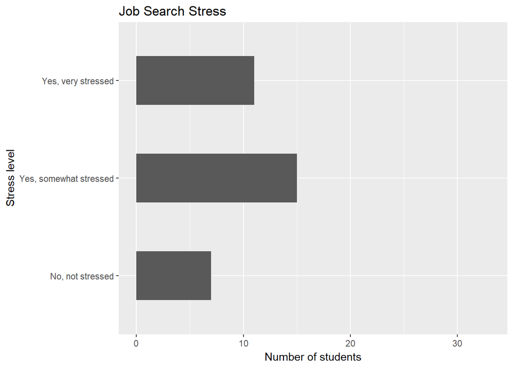

Our goal was therefore to illuminate the effectiveness of different job search resources so that students can allocate their time most productively. Our model focuses on making recommendations that minimize excess effort and time spent job searching. These include recommendations about what skills you should develop in the long term and what resources you should use in the short term.

# Key Findings

Recommendations to guide immediate actions:

- Avoid relying too heavily on online resources like LinkedIn, online job postings, etc.
- After applying to a lot of online postings (more than around 25), most people spend less time on cover letters and resumes. It’s better to invest more effort into fewer applications.
- If you are heavily dependent on online resources, solicit your friends/family/professors/etc. to see if anyone has connections to your organizations of interest. Leverage the ones you find.
- You have to use resources a lot to get offers from them. Doing something a little bit is unlikely to be a good use of time. Instead, pick a few resources to use and get really good at them.

Recommendations to guide long term planning:

- A high cumulative GPA and internship experience both correlate with shorter job search times. If you’ve focused more on one of these areas than the other, you’re not doomed. If you haven’t focused on either, you should aim to improve in at least one of the two.
- Push yourself to work on developing interpersonal skills. People who said they were good at networking and interviewing tended to have the shortest job searches compared to people who were good at writing cover letters/resumes or were knowledgeable about their area of study.

# Model

Our original model approached our question dividing respondents into two groups: those who accepted a job offer in under 3 months of searching, and those who did not. We chose the 3 month cutoff because about half of respondents fell on one side and half on the other.

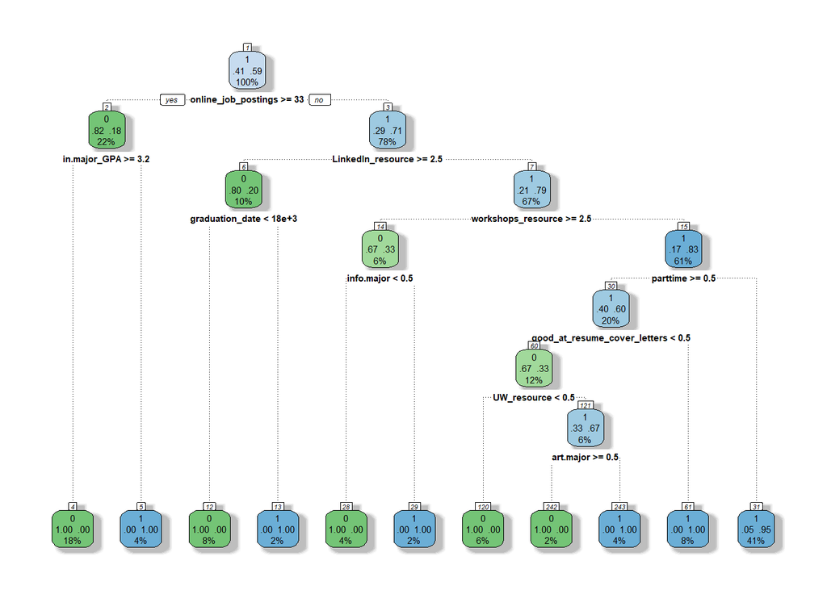

Our solution was to analyze only individuals who got offers in the first couple months of their job search under the assumption they would have only had the chance to utilize one strategy. We looked for a natural cutoff in the data but found none so four months was chosen arbitrarily. While this method prevents us from analyzing strategies that did not work it allows us to definitively point to the strategies that did work.

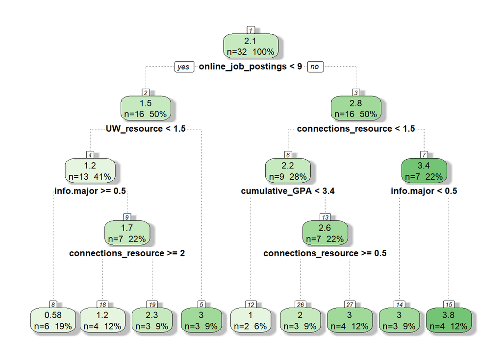

While not every aspect of the revised model makes perfect sense, the model’s issues - unlike those in the original model - have more to do with our dataset’s small sample size than with the model’s design itself.

## Supplemental analysis

A high cumulative GPA and internship experience both correlate with shorter job search times. If you’ve focused more on one of these areas than the other, you’re not doomed. If you haven’t focused on either, you should aim to improve in at least one of the two. The correlation is not strong; there are a number of students who find jobs quickly who have a low GPA or no internship experience. However, there is a general pattern that these are two factors that can decrease your job search time.

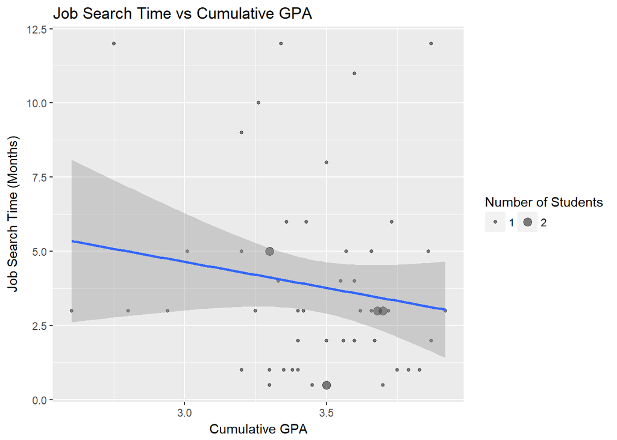

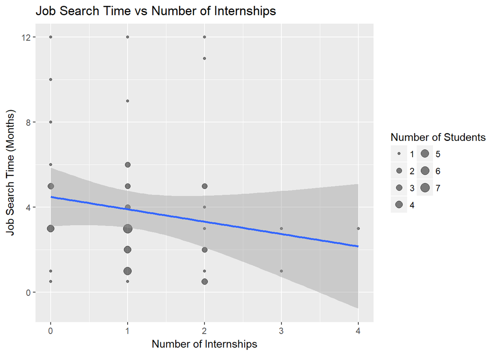

## Lasso Regression

For the multi-feature problem in linear regression, we used L1 regulation Lasso to model mean squared error.

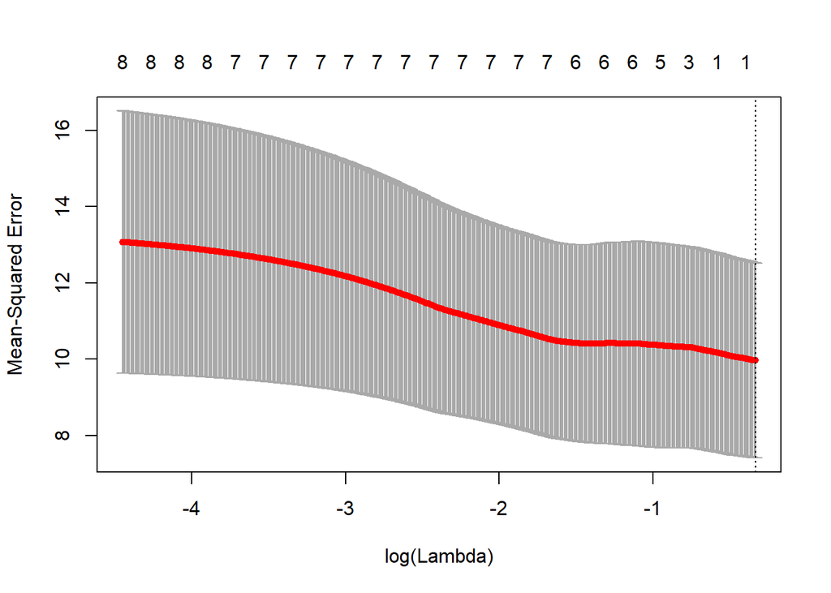

The x-axis is log(Lambda) and Lambda is an input to the model fitting process. The value on the top is the number of coefficients for the linear model that are not zero. In our model, the lasso removes more and more coefficients by setting them to zero as lambda incresases. Thus, the model is telling that less number of factors makes better result for success in employment.

## Coefficient of Lasso Regression

We analyzed the coefficient of Lasso model in order to observe the pattern.

```
## 6 x 5 sparse Matrix of class "dgCMatrix"
##                                  s5         s6         s7         s8
## (Intercept)              3.80421102 3.79732248 3.79049716 3.78373448
## data.resume_hrs          .          .          .          .
## data.cover_letter_hours  .          .          .          .
## data.self.confidence     .          .          .          .
## data.online_job_postings .          .          .          .
## data.no_career_fairs     0.01840016 0.02197949 0.02552598 0.02903993
##                                  s9
## (Intercept)              3.77703387
## data.resume_hrs          .
## data.cover_letter_hours  .
## data.self.confidence     .
## data.online_job_postings .
## data.no_career_fairs     0.03252162
```

## Scatter Plot

We plotted the observation from the coefficeint of lasso model.

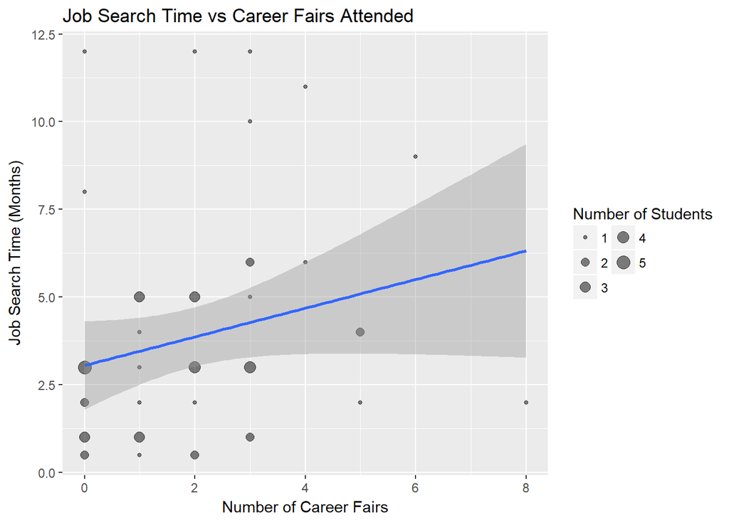

The graph tells us that more attendance at career fairs results in a higher number of months to find employment. This most likely just means that people who are initially unsuccessful at finding a job will continue going to career fairs, not that attending more career fairs actually makes the job search take longer.

# Limitations

This study surveyed 53 University of Washington undergraduate students and recent graduates. Because of the small sample size, it is possible that the correlations we have found will not persist with a larger sample size. Our analysis describes this sample only. Additionally, we acknowledge that there are other factors that can influence job search time, such as available positions and the pool of other candidates. This is a tool to help make decisions, not a definite formula that will guarantee immediate job offers.